# End-to-End workflow for DGE using Affymetrix microarrays - Cardiac Neural Crest Cells

Juan C. Sanchez-Arias

16/11/2021

## Introduction

Differential gene expression (DGE) analysis of Affymetrix microarrays of cardiac neural crest cells using Klaus B, Reisenauer S (2019). maEndToEnd: [An end to end workflow for differential gene expression using Affymetrix microarrays.](https://bioconductor.riken.jp/packages/3.9/workflows/html/maEndToEnd.html) Bioconductor workflow.

```r
suppressPackageStartupMessages({library("maEndToEnd")})
```

```r
#General Bioconductor packages
    library(Biobase)
    library(oligoClasses)

#Annotation and data import packages
    library(ArrayExpress)
    library(pd.hugene.1.0.st.v1)
    library(hugene10sttranscriptcluster.db)

#Quality control and pre-processing packages
    library(oligo)
    library(arrayQualityMetrics)

#Analysis and statistics packages
    library(limma)
    library(topGO)
    library(ReactomePA)
    library(clusterProfiler)

#Plotting and color options packages
    library(gplots)
    library(ggplot2)
    library(geneplotter)
    library(RColorBrewer)
    library(pheatmap)
    library(enrichplot)

#Formatting/documentation packages
   #library(rmarkdown)
   #library(BiocStyle)
    library(dplyr)
    library(tidyr)

#Helpers:
    library(stringr)
    library(matrixStats)
    library(genefilter)
    library(openxlsx)
```

## Downloading raw data from ArrayExpress

From Klaus B, Reisenauer S (2019). maEndToEnd: >The first step of the analysis is to download the raw data CEL files. These files are produced by the array scanner software and contain the measured probe intensities.

For this analysis on cardiac neural crest cells, I will use the data deposited with study **E-GEOD-41179**.

```r
raw_data_dir <- tempdir()

if (!dir.exists(raw_data_dir)) {
    dir.create(raw_data_dir)
}
```

From Klaus B, Reisenauer S (2019). maEndToEnd:

> Each ArrayExpress data set has a landing page summarizing the data set, and we use the `getAE` function from the ArrayExpress Bioconductor package to obtain the ftp links to the raw data files (Data from Dai X, Jiang W, Zhang Q, Xu L et al. Requirement for integrin-linked kinase in neural crest migration and differentiation and outflow tract morphogenesis. BMC Biol 2013 Oct 16;11:107. PMID: 24131868). With the code below, we download the raw data (also including annotation data) from ArrayExpress (2) by using the `getAE`-function. The data are saved in the raw_data_dir created above. The names of the downloaded files are returned as a list."

```r
anno_AE <- getAE("E-GEOD-41179", path = raw_data_dir, type = "raw")
```

```
## Copying raw data files
```

```
## Unpacking data files
```

## Background information on the data

From Klaus B, Reisenauer S (2019). maEndToEnd:

> Each dataset in ArrayExpress is stored following MAGE-TAB (MicroArray Gene Expression Tabular) specifications:
- Investigation Description Format (IDF): contains top level information about the experiment including title, description, submitter contact details and protocols
- Array Design Format (ADF)
- Sample and Data Relationship Format (SDRF): contains essential information on the experimental samples, e.g. the experimental group(s) they belong to.
- Raw data files
- Processed data files

> Before we move on to the actual raw data import, we will briefly introduce the `ExpressionSet` class contained in the `Biobase` package. It is commonly used to store microarray data in Bioconductor.

## Bioconductor ExpressionSets

From Klaus B, Reisenauer S (2019). maEndToEnd:

> Genomic data can be very complex, usually consisting of a number of different components, e.g. information on the experimental samples, annotation of genomic features measured as well as the experimental data itself. In Bioconductor, the approach is taken that these components should be stored in a single structure to easily manage the data.

> The package `Biobase` contains standardized data structures to represent genomic data. The `ExpressionSet` class is designed to combine several different sources of information (i.e. as contained in the various MAGE-TAB files) into a single convenient structure. An `ExpressionSet` can be manipulated (e.g., subsetted, copied), and is the input to or output of many Bioconductor functions.

The data in an `ExpressionSet` consist of:

- assayData: Expression data from microarray experiments with microarray probes in rows and sample identifiers in - columns
- metaData
- phenoData: A description of the samples in the experiment with sample identifiers in rows and description elements in columns; holds the content of the SDRF file
- featureData: metadata about the features on the chip or technology used for the experiment with same rows as assayData by default and freely assignable columns
- further annotations for the features, for example gene annotations from biomedical databases (annotation). experimentData: A flexible structure to describe the experiment.

> The ExpressionSet class coordinates all of these data, so that one does not have to worry about the details. However, one should keep in mind that the rownames of the phenoData have to match the column names of the assay data, while the row names of the assay data have to match the row names of the featureData. This is illustrated in Figure 1.

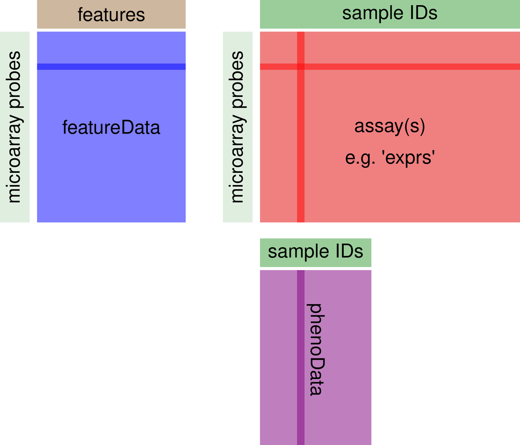

>You can use the functions `pData` and `fData` to extract the sample and feature annotation, respectively, from an ExpressionSet. The function `exprs` will return the expression data itself as a matrix.

## Import of annotation data and microarray expression data as “ExpressionSet”

From Klaus B, Reisenauer S (2019). maEndToEnd:

> We import the SDRF file with the `read.delim` function from the raw data folder in order to obtain the sample annotation.

> The sample names are given in the column Array.Data.File of the SDRF data table and will be used as rownames for the SDRF file.

> We turn the SDRF table into an `AnnotatedDataFrame` from the `Biobase` package that we will need later to create an `ExpressionSet` for our data (3).